# Assessment 4 R Data Analysis

Natasha Ford, Kahla Finch, Devanshee Alpeshkumar Gandhi

2024-09-25

# **Part 1**

## Gene Expression Data

The file “gene_expression.tsv” contains RNA-seq count data for three samples of interest.

### Download Data files

```r
URL_P1="https://raw.githubusercontent.com/ghazkha/Assessment4/refs/heads/main/gene_expression.tsv"
download.file(URL_P1,destfile="Gene_Expression.csv")
```

Gene expression file was downloaded using the download.file() command

## **Q1**

### Gene Expression file read in as table.

```r
Gene_Expression <- read.table("https://raw.githubusercontent.com/ghazkha/Assessment4/refs/heads/main/gene_expression.tsv",stringsAsFactors = FALSE, header=TRUE, row.names=1)

head(Gene_Expression)
```

```
##                               GTEX.1117F.0226.SM.5GZZ7 GTEX.1117F.0426.SM.5EGHI
## ENSG00000223972.5_DDX11L1                            0                        0
## ENSG00000227232.5_WASH7P                           187                      109
## ENSG00000278267.1_MIR6859-1                          0                        0
## ENSG00000243485.5_MIR1302-2HG                        1                        0
## ENSG00000237613.2_FAM138A                            0                        0
## ENSG00000268020.3_OR4G4P                             0                        1
##                               GTEX.1117F.0526.SM.5EGHJ
## ENSG00000223972.5_DDX11L1                            0
## ENSG00000227232.5_WASH7P                           143
## ENSG00000278267.1_MIR6859-1                          1
## ENSG00000243485.5_MIR1302-2HG                        0
## ENSG00000237613.2_FAM138A                            0
## ENSG00000268020.3_OR4G4P                             0
```

Required package, “readr” installed and loaded using install.packages() and library() command. Data read in as table with the read.table command, the row.names=1 argument creates rows with the gene identifiers as the names. The head() function displays the first 6 lines of the table.

## **Q2**

### Mean data of Gene expression added to table as new column

```r
Gene_Expression$Mean_value <- rowMeans(Gene_Expression, na.rm = TRUE)
head(Gene_Expression)
```

```
##                               GTEX.1117F.0226.SM.5GZZ7 GTEX.1117F.0426.SM.5EGHI
## ENSG00000223972.5_DDX11L1                            0                        0
## ENSG00000227232.5_WASH7P                           187                      109
## ENSG00000278267.1_MIR6859-1                          0                        0
## ENSG00000243485.5_MIR1302-2HG                        1                        0
## ENSG00000237613.2_FAM138A                            0                        0
## ENSG00000268020.3_OR4G4P                             0                        1
##                               GTEX.1117F.0526.SM.5EGHJ  Mean_value
## ENSG00000223972.5_DDX11L1                            0   0.0000000
## ENSG00000227232.5_WASH7P                           143 146.3333333
## ENSG00000278267.1_MIR6859-1                          1   0.3333333
## ENSG00000243485.5_MIR1302-2HG                        0   0.3333333
## ENSG00000237613.2_FAM138A                            0   0.0000000
## ENSG00000268020.3_OR4G4P                             0   0.3333333
```

rowMeans() is used to calculate the mean value of each row in the data file, those values are then subset using Gene_Expression$Mean_value <- into the file. The head() function displays the first 6 lines of the table.

## **Q3**

### 10 genes with the highest mean expression

```r
Sorted_Genes <- Gene_Expression[order(-Gene_Expression$Mean_value), ]
Top10_Mean <- head(Sorted_Genes, 10)
print(Top10_Mean)
```

```
##                           GTEX.1117F.0226.SM.5GZZ7 GTEX.1117F.0426.SM.5EGHI
## ENSG00000198804.2_MT-CO1                    267250                  1101779
## ENSG00000198886.2_MT-ND4                    273188                   991891
## ENSG00000198938.2_MT-CO3                    250277                  1041376
## ENSG00000198888.2_MT-ND1                    243853                   772966
## ENSG00000198899.2_MT-ATP6                   141374                   696715
## ENSG00000198727.2_MT-CYB                    127194                   638209
## ENSG00000198763.3_MT-ND2                    159303                   543786
## ENSG00000211445.11_GPX3                     464959                    39396
## ENSG00000198712.1_MT-CO2                    128858                   545360
## ENSG00000156508.17_EEF1A1                   317642                    39573
##                           GTEX.1117F.0526.SM.5EGHJ Mean_value
## ENSG00000198804.2_MT-CO1                    218923   529317.3
## ENSG00000198886.2_MT-ND4                    277628   514235.7
## ENSG00000198938.2_MT-CO3                    223178   504943.7
## ENSG00000198888.2_MT-ND1                    194032   403617.0
## ENSG00000198899.2_MT-ATP6                   151166   329751.7
## ENSG00000198727.2_MT-CYB                    141359   302254.0
## ENSG00000198763.3_MT-ND2                    149564   284217.7
## ENSG00000211445.11_GPX3                     306070   270141.7
## ENSG00000198712.1_MT-CO2                    122816   265678.0
## ENSG00000156508.17_EEF1A1                   339347   232187.3
```

The order() function sorts the data based on the mean values, the - argument must be used to sort in descending order. head(sorted) subsets the top 10 rows into Top10_Mean which can be displayed using print().

## **Q4**

### Number of genes with a mean <10

```r
Low_Mean <- subset(Gene_Expression, Mean_value < 10)
nrow(Low_Mean)
```

```
## [1] 35988
```

Subset taken of gene expression data with a mean value of less than 10. The rows in the resulting data are counted to get the amount of genes with a mean under 10.

## **Q5**

### Histogram of Mean Values

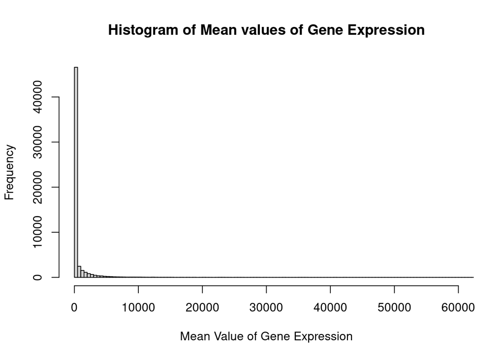

```r
hist(Gene_Expression$Mean_value,breaks=1000, xlim = c(0,60000), xlab = "Mean Value of Gene Expression",main="Histogram of Mean values of Gene Expression")
```

The Histogram shown in the above figure displays the mean values of the gene expression data.The histogram was created with the hist() command, which produces a histogram plot.

## **Q6**

## Growth Data

The file “growth_data.csv” contains tree circumference measurements for trees growing at both a control site and a treatment site. The trees were planted 20 years ago.

### Importing growth data csv file into R

```r
growth_data_URL <- "https://raw.githubusercontent.com/ghazkha/Assessment4/refs/heads/main/growth_data.csv"
download.file(growth_data_URL,destfile="growth_data")

growth_data <- read.csv("growth_data")
head(growth_data)
```

```
##        Site TreeID Circumf_2005_cm Circumf_2010_cm Circumf_2015_cm
## 1 northeast   A012             5.2            10.1            19.9
## 2 southwest   A039             4.9             9.6            18.9
## 3 southwest   A010             3.7             7.3            14.3
## 4 northeast   A087             3.8             6.5            10.9
## 5 southwest   A074             3.8             6.4            10.9
## 6 northeast   A008             5.9            10.0            16.8
##   Circumf_2020_cm
## 1            38.9
## 2            37.0
## 3            28.1
## 4            18.5
## 5            18.4
## 6            28.4
```

The growth data csv file was converted into a R object, via the download.file command, the first six outputs are shown via the head() command.

### Column names of Growth Data

```r
colnames(growth_data)
```

```
## [1] "Site"            "TreeID"          "Circumf_2005_cm" "Circumf_2010_cm"
## [5] "Circumf_2015_cm" "Circumf_2020_cm"
```

To determine the column names of the growth data file, the command colnames() was used, and the column names of “Site”,“TreeID”, “Circumf_2005_cm”, “Circumf_2010_cm”, “Circumf_2015_cm”and “Circumf_2020_cm” can be seen in the output above.

## **Q7**

### Mean and standard deviation at notheast and southwest sites at 2005 and 2020

#### Mean and standard deviation of northeast site at 2005

```r
growth_northeast_2005 <- subset(growth_data, Site == "northeast", select = c("Circumf_2005_cm"))
head(growth_northeast_2005)
```

```
##    Circumf_2005_cm
## 1              5.2
## 4              3.8
## 6              5.9
## 7              4.4
## 8              5.3
## 12             3.5
```

```r
mean_growth_northeast_2005 <- mean(growth_northeast_2005$Circumf_2005_cm)
mean_growth_northeast_2005
```

```
## [1] 5.292
```

```r
SD_growth_northeast_2005 <- sd(growth_northeast_2005$Circumf_2005_cm)
SD_growth_northeast_2005
```

```
## [1] 0.9140267
```

To determine the mean of 5.292 cm and standard deviation of 0.914 cm at the northeast site at 2005, the complete growth data was subsetted into northeast 2005 and mean() and SD() commands were used.

#### Mean and standard deviation of northeast site at 2020

```r
growth_northeast_2020 <- subset(growth_data, Site == "northeast", select = c("Circumf_2020_cm"))
head(growth_northeast_2020)
```

```
##    Circumf_2020_cm
## 1             38.9
## 4             18.5
## 6             28.4
## 7             50.0
## 8             25.8
## 12            26.0
```

```r
mean_growth_northeast_2020 <- mean(growth_northeast_2020$Circumf_2020_cm)
mean_growth_northeast_2020
```

```
## [1] 54.228
```

```r
SD_growth_northeast_2020 <- sd(growth_northeast_2020$Circumf_2020_cm)
SD_growth_northeast_2020
```

```
## [1] 25.22795
```

To determine the mean of 54.228 cm and standard deviation of 25.22795 cm at the northeast site at 2020, the complete growth data was subsetted into northeast 2020 and mean() and SD() commands were used.

#### Mean and standard deviation of southwest site at 2005

```r
growth_southwest_2005 <- subset(growth_data, Site == "southwest", select = c("Circumf_2005_cm"))
head(growth_southwest_2005)
```

```
##    Circumf_2005_cm
## 2              4.9
## 3              3.7
## 5              3.8
## 9              7.1
## 10             3.8
## 11             5.4
```

```r
mean_growth_southwest_2005 <- mean(growth_southwest_2005$Circumf_2005_cm)
mean_growth_southwest_2005
```

```
## [1] 4.862
```

```r
SD_growth_southwest_2005 <- sd(growth_southwest_2005$Circumf_2005_cm)
SD_growth_southwest_2005
```

```
## [1] 1.147471
```

To determine the mean of 4.862 cm and standard deviation of 1.147471 cm at the southwest site at 2005, the complete growth data was subsetted into southwest 2005 and mean() and SD() commands were used.

#### Mean and standard deviation of southwest site at 2020

```r
growth_southwest_2020 <- subset(growth_data, Site == "southwest", select = c("Circumf_2020_cm"))
head(growth_southwest_2020)
```

```
##    Circumf_2020_cm
## 2             37.0
## 3             28.1
## 5             18.4
## 9             34.2
## 10            28.4
## 11            40.5
```

```r
mean_growth_southwest_2020 <- mean(growth_southwest_2020$Circumf_2020_cm)
mean_growth_southwest_2020
```

```
## [1] 45.596
```

```r
SD_growth_southwest_2020 <- sd(growth_southwest_2020$Circumf_2020_cm)
SD_growth_southwest_2020
```

```
## [1] 17.87345
```

To determine the mean of 45.596 cm and standard deviation of 17.87345 cm at the southwest site at 2020, the complete growth data was subsetted into southwest 2020 and mean() and SD() commands were used.

### Table summary of mean and standard deviation

```r
mean_SD_table <- data.frame(col1 = c((mean_growth_northeast_2005),(SD_growth_northeast_2005)),
                      col2 = c((mean_growth_northeast_2020),(SD_growth_northeast_2020)),
                      col3 = c((mean_growth_southwest_2005),(SD_growth_southwest_2005)),
                      col4 = c((mean_growth_southwest_2020),(SD_growth_southwest_2020)))
colnames(mean_SD_table) <- c("Northeast 2005","Northeast 2020","Southwest 2005","Southwest 2020")
rownames(mean_SD_table) <- c("Mean", "Standard Deviation")
mean_SD_table
```

```
##                    Northeast 2005 Northeast 2020 Southwest 2005 Southwest 2020
## Mean                    5.2920000       54.22800       4.862000       45.59600
## Standard Deviation      0.9140267       25.22795       1.147471       17.87345
```

To provide the table above, a data frame was created with the mean and standard deviation results from the northeast and southwest sites and 2005 and 2020.

## **Q8**

### Box plot for tree circumference in 2005 (start of the study)

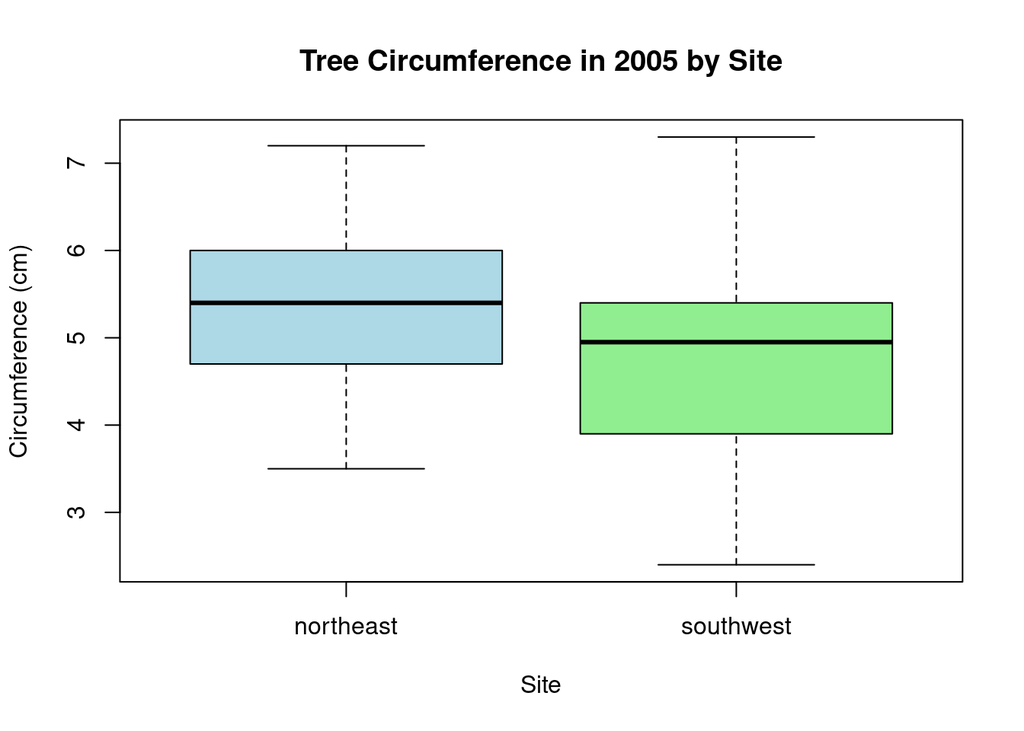

```r
boxplot(growth_data$Circumf_2005_cm ~ growth_data$Site,
        main = "Tree Circumference in 2005 by Site",
        xlab = "Site", ylab = "Circumference (cm)",
        col = c("lightblue", "lightgreen"))
```

### Box plot for tree circumference in 2020 (end of the study)

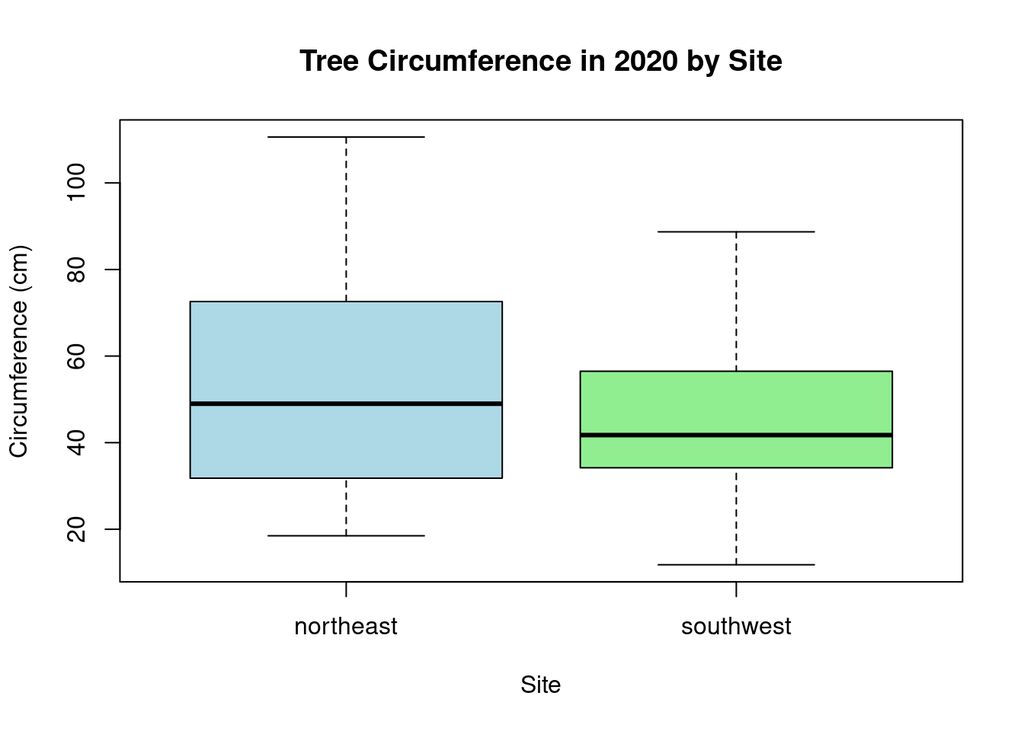

```r
boxplot(growth_data$Circumf_2020_cm ~ growth_data$Site,
        main = "Tree Circumference in 2020 by Site",
        xlab = "Site", ylab = "Circumference (cm)",
        col = c("lightblue", "lightgreen"))
```

Shown above are two separate box plots. The first box will show how the tree circumference is distributed across both sites in 2005, and the second box will show the distribution in 2020. This gives us an understanding of growth over time and how it differs between the two sites. The plots above were created with the boxplot() command.

## **Q9**

### Calculating the growth between 2010 and 2020 for both sites

```r
growth_data$Growth_10yr <- growth_data$Circumf_2020_cm - growth_data$Circumf_2010_cm
```

### Subsetting the data for northeast and southwest sites

```r
growth_northeast_10yr <- subset(growth_data, Site == "northeast", select = c("Growth_10yr"))
growth_southwest_10yr <- subset(growth_data, Site == "southwest", select = c("Growth_10yr"))
```

### Calculating the mean growth over the last 10 years for each site

```r
mean_growth_northeast_10yr <- mean(growth_northeast_10yr$Growth_10yr)
mean_growth_southwest_10yr <- mean(growth_southwest_10yr$Growth_10yr)
```

### Outputting the mean growth values

```r
mean_growth_northeast_10yr
```

```
## [1] 42.94
```

```r
mean_growth_southwest_10yr
```

```
## [1] 35.49
```

This will give two numeric values:

Mean growth at the northeast site over the last 10 years is 42.94 cm Mean growth at the southwest site over the last 10 years is 35.49 cm

These values tell us how much the tree circumference increased on average at each site between 2010 and 2020.

## **Q10**

### Performing t-test to compare the 10-year growth between the two sites

```r
t_test_result <- t.test(growth_data$Growth_10yr ~ growth_data$Site)
```

### Outputting the p-value from the t-test

```r
t_test_result$p.value
```

```
## [1] 0.06229256
```

The p-value will be a number between 0 and 1:

If the p-value < 0.05, we conclude that the 10-year growth is significantly different between the two sites. If the p-value >= 0.05, we conclude that there is no significant difference in growth between the two sites. As the p-value had a result of 0.062, we can conclude there is no significant difference in growth between the 2 sites.

# **Part 2**

## **Q1**

### Downloading Coding DNA of *Salmonella*

```r
salmonella_URL <- "https://ftp.ensemblgenomes.ebi.ac.uk/pub/bacteria/release-59/fasta/bacteria_50_collection/salmonella_enterica_subsp_enterica_serovar_weltevreden_gca_005518735/cds/Salmonella_enterica_subsp_enterica_serovar_weltevreden_gca_005518735.ASM551873v1.cds.all.fa.gz"
download.file(salmonella_URL,destfile = "Salmonella.fa.gz")
gunzip("Salmonella.fa.gz")

salmonella <- seqinr::read.fasta("Salmonella.fa")
```

To download the *Salmonella enterica* subsp. enterica serovar Weltevreden (GCA_005518735), (*Salmonella*) file, the download.file command was used, along with the gunzip command to remove the zip format from the FASTA file.

### Downloading Coding DNA of *E.coli*

```r
ecoli_URL <- "http://ftp.ensemblgenomes.org/pub/bacteria/release-53/fasta/bacteria_0_collection/escherichia_coli_str_k_12_substr_mg1655_gca_000005845/cds/Escherichia_coli_str_k_12_substr_mg1655_gca_000005845.ASM584v2.cds.all.fa.gz"

download.file(ecoli_URL,destfile = "ecoli.fa.gz")
gunzip("ecoli.fa.gz")

e_coli <- seqinr::read.fasta("ecoli.fa")
```

To download the *Escherichia coli* str. K-12 substr. MG1655 str. K12 (GCA_000005845) (*E.coli*) file, the download.file command was used, along with the gunzip command to remove the zip format from the FASTA file.

### Table displaying Coding DNA sequence legnth of *Salmonella* and *E-coli*

```r
Salmonella_E.coli <- as.table(rbind(c(length(salmonella),length(e_coli))))
colnames(Salmonella_E.coli) <- c("Salmonella","E-coli")
rownames(Salmonella_E.coli) <- "Coding DNA sequences"
Salmonella_E.coli
```

```
##                      Salmonella E-coli
## Coding DNA sequences       4585   4239
```

The table shown above displays the amount of Coding DNA sequences, we can see a difference in length between *Salmonella* and *E.coli*, with *Salmonella* having 4585 coding DNA sequences and *E.coli* having 4239 coding DNA sequences.

## **Q2**

### Coding DNA in *Salmonella* and *E-coli*

```r
salmonella_length <-as.numeric(summary(salmonella)[,1])

sum(salmonella_length)
```

```
## [1] 4294851
```

```r
e_coli_length <- as.numeric(summary(e_coli)[,1])

sum(e_coli_length)
```

```
## [1] 3978528
```

### Table presenting total coding DNA in *Salmonella* and *E-coli*

```r
CodingDNA <- as.table(rbind(c(sum(salmonella_length),sum(e_coli_length))))
colnames(CodingDNA) <- c("Salmonella","E-coli")
rownames(CodingDNA) <- "Total Coding DNA"
CodingDNA
```

```
##                  Salmonella  E-coli
## Total Coding DNA    4294851 3978528
```

The table shown above displays the amount of Coding DNA in total in both *Salmonella* and *E.coli*, we can see a difference in total amount of DNA between *Salmonella* and *E.coli*, with *Salmonella* having 4294851 coding DNA base pairs and *E.coli* having 3978528 coding DNA base pairs.

## **Q3**

### Length of all coding sequences in *Salmonella*

```r
salmonella_csl <- sapply(salmonella, length)
head(salmonella_csl,25)
```

```
## ENSB:rzMRPrOXj2f6n3A ENSB:x3MzlaR1iM6Op6v ENSB:btfdQZt4_vWjqOV
##                  417                  402                 2613
## ENSB:IZ64ldiL3-oOAYf ENSB:9CMZHlFso1POuRQ ENSB:WDGo7WHsQXy-ZVK
##                 1314                  165                  918
## ENSB:nxZOXcqpENLAhq- ENSB:Pdq_njih_D4z76t ENSB:doMeXiedV9pXccR
##                  879                 2799                 1080
## ENSB:kQ3Q9ymg3iP1FNt ENSB:HIcMhKuQYYbSiCI ENSB:kMzQPuEK1M6h21v
##                 1335                 1545                 1563
## ENSB:PybEbgTbnAhpxJ4 ENSB:g7VWNp8A7dOsFEs ENSB:CqxksGF2_zG4Fwf
##                  852                  201                  627
## ENSB:qcIxBcPJXPy3xCH ENSB:2fftfGVWMOg5gVb ENSB:asHCFULnp2Cpguy
##                  438                 1593                 1419
## ENSB:Szs8QJYwEVWVtvU ENSB:Rw0LhdcFy6IGZRX ENSB:Pa_nz_ONaNE4x4I
##                  996                  189                 1428
## ENSB:0K5ccUl1Vz1MFBH ENSB:_-Kn39gDsVlrpn5 ENSB:iK0yimEqOtEzOGl
##                 1017                 1326                  324
## ENSB:821CJ4HgDYyKI6H
##                  159
```

sapply() works as a loop function when calculating the length of each sequence in the *Salmonella* data. the head() function is utilised to show the first 25 sequences lengths in an effort to minimise the size of the rmd file. print can be used in it’s place for a more complete view.

### Length of all coding sequences in *E.coli*

```r
e_coli_csl <- sapply(e_coli, length)
head(e_coli_csl,25)
```

```
## AAC73112 AAC73113 AAC73114 AAC73115 AAC73116 AAC73117 AAC73118 AAC73119
##       66     2463      933     1287      297      777     1431      954
## AAC73120 AAC73121 AAC73122 AYC08161 AAC73124 AAC73125 AAC73126 AAC73127
##      588      567      714      486      405     1917     1131     1113
## AAC73129 AAT48122 AAC73130 AAC73131 AAC73132 AAC73133 AAC73134 AAC73135
##      210      153     1167      906      504      276      264      219
## AAC73136
##      942
```

sapply() works as a loop function when calculating the length of each sequence in the *E.coli* data. the head() function is utilised to show the first 25 sequences lengths in an effort to minimise the size of the rmd file. print can be used in it’s place for a more complete view.

### Boxplot of coding sequence length

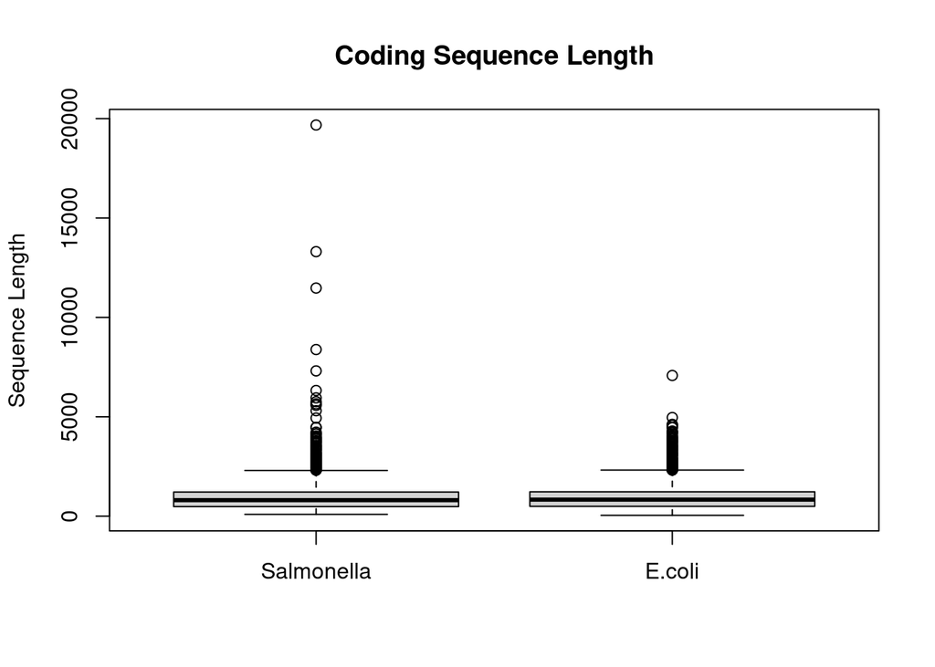

```r
boxplot(salmonella_csl, e_coli_csl,
        ylab="Sequence Length",
        main="Coding Sequence Length",
        names = c("Salmonella","E.coli"))
```

The boxplot() function creates a boxplot of both the *Salmonella* and the *E.coli* data. The heading of the plot is changed with the ‘main’ argument, the y axis label with ‘ylab’ and the names of each individual plot with the ‘names’ argument.

### Mean and Median coding sequence length of *Salmonella*

```r
mean(salmonella_csl)
```

```
## [1] 936.7178
```

The mean() command calculates the average value, in this case the length, of every sequence.The mean for the length of *Salmonella* sequences is 936.7178.

```r
median(salmonella_csl)
```

```
## [1] 804
```

The median() command calculates the middle value of all the sequences.The median for the length of *Salmonella* sequences is 804.

### Mean and Median coding sequence length of *E.coli*

```r
mean(e_coli_csl)
```

```
## [1] 938.5534
```

The mean() command calculates the average value, in this case the length, of every sequence.The mean for the length of *E.coli* sequences is 938.5534.

```r
median(e_coli_csl)
```

```
## [1] 831
```

The median() command calculates the middle value of all the sequences.The median for the length of *E.coli* sequences is 831.

## **Q4**

### Frequency of DNA bases

```r
salmonella_DNA <- unlist(salmonella)
salmonella_DNA_comp <- count(salmonella_DNA,1)
salmonella_DNA_prop <- salmonella_DNA_comp/sum(salmonella_DNA_comp)
salmonella_DNA_prop
```

```
##
##         a         c         g         t
## 0.2339450 0.2513941 0.2808617 0.2337993
```

```r
e_coli_DNA <- unlist(e_coli)
e_coli_DNA_comp <- count(e_coli_DNA,1)
e_coli_DNA_prop <- e_coli_DNA_comp/sum(e_coli_DNA_comp)
e_coli_DNA_prop
```

```
##
##         a         c         g         t
## 0.2402316 0.2457175 0.2735939 0.2404570
```

The unlist() command converts the list data into a vector making it easier for analysis. count() is used to calculate the amount of each nucleotide in each sequence, <- stores the results in the _comp values. Dividing the _comp data by the sum of itself determines the frequency as a percentage in decimal form.

### Bar plot for *Salmonella* nucleotide frequency

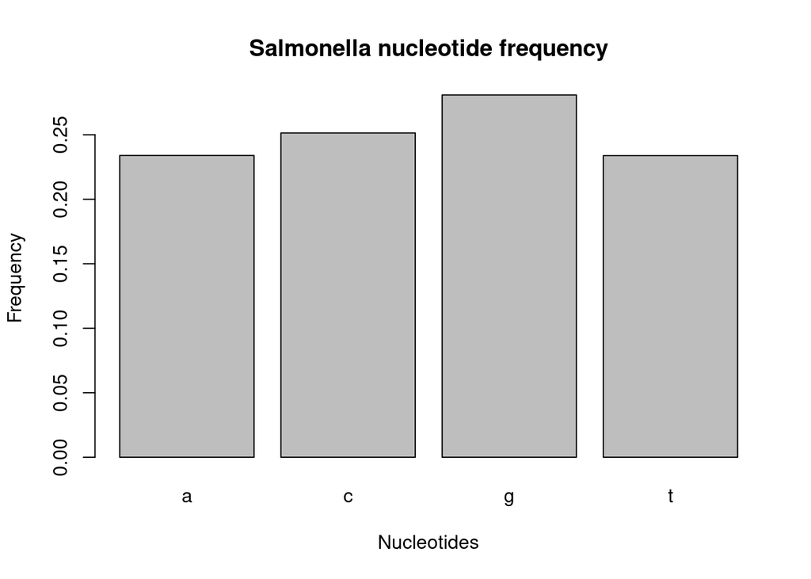

```r
barplot(salmonella_DNA_prop,xlab="Nucleotides",ylab="Frequency", main="Salmonella nucleotide frequency")
```

The frequency of nucleotides is displayed as a barplot with the barplot() command. The plot heading is determined with “main”, the x and y axis labels are determined using “xlab” and “ylab” respectively.

### Bar plot for *E.coli* nucleotide frequency

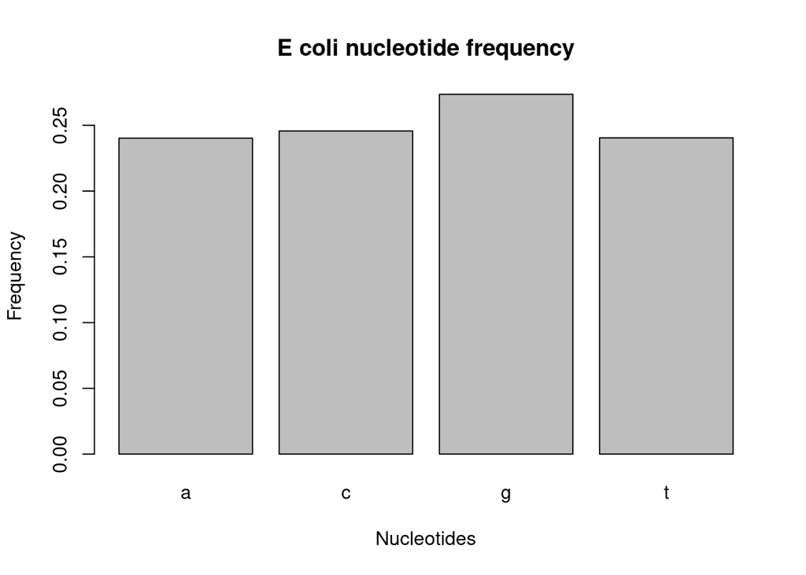

```r
barplot(e_coli_DNA_prop,xlab="Nucleotides",ylab="Frequency", main="E coli nucleotide frequency")
```

The frequency of nucleotides is displayed as a barplot with the barplot() command. The plot heading is determined with “main”, the x and y axis labels are determined using “xlab” and “ylab” respectively.

### *Salmonella* Protein sequence frequency

```r
salmonella_prot <- lapply(salmonella, translate)

salmonella_aa <- unique(salmonella_prot[[2]])
salmonella_aa <- salmonella_aa[salmonella_aa != "*"]

salmonella_aa_len <- length(salmonella_aa)

salmonella_aa_count <- lapply(salmonella_prot, function(sequence) {
  count(sequence, wordsize = 1, alphabet = salmonella_aa)
})

salmonella_aa_table <- do.call(rbind, salmonella_aa_count)

salmonella_aa_totals <- colSums(salmonella_aa_table)

salmonella_aa_prop <- salmonella_aa_totals/sum(salmonella_aa_totals)

salmonella_aa_prop
```

```
##          A          D          E          F          G          I          K
## 0.10083505 0.05415912 0.05817653 0.04002090 0.07623562 0.06161545 0.04450283
##          L          M          N          P          Q          R          S
## 0.11030698 0.02847749 0.03952880 0.04634278 0.04553858 0.05850387 0.06015874
##          T          V          W          Y
## 0.05697239 0.07288451 0.01584825 0.02989211
```

To translate all sequences in the data to proteins sequences, the lapply() command is applied. To define the amino acid alphabet, unique() extracts unique amino acids while salmonella_aa[salmonella_aa != “*”] removes any unknown amino acids. This is then used as a reference when using lapply(x,count()) to calculate the amount of each amino acid in the sequences. do.call(rbind,x) is usually for combining more complex amounts of data into 1 data frame, however it is still effective here. colSums calculates the total of each column, in this case, it add the amount of each amino acid across the sequences. The proportion of each total is calculated by dividing each total by the overall total. The results are then displayed.

### *E.coli* Protein sequence frequency

```r
e_coli_prot <- lapply(e_coli, translate)

e_coli_aa <- unique(e_coli_prot[[2]])
e_coli_aa <- e_coli_aa[e_coli_aa != "*"]

e_coli_aa_len <- length(e_coli_aa)

e_coli_aa_count <- lapply(e_coli_prot, function(sequence) {
  count(sequence, wordsize = 1, alphabet = e_coli_aa)
})

e_coli_aa_table <- do.call(rbind, e_coli_aa_count)

e_coli_aa_totals <- colSums(e_coli_aa_table)

e_coli_aa_prop <- e_coli_aa_totals/sum(e_coli_aa_totals)

e_coli_aa_prop
```

```
##          A          C          D          E          F          G          H
## 0.09541075 0.01163142 0.05128535 0.05774708 0.03900413 0.07356326 0.02269019
##          I          K          L          M          N          P          Q
## 0.06014734 0.04396049 0.10721464 0.02799453 0.03896025 0.04440454 0.04447943
##          R          S          T          V          W          Y
## 0.05530596 0.05780306 0.05372798 0.07109945 0.01527758 0.02829257
```

To translate all sequences in the data to proteins sequences, the lapply() command is applied. To define the amino acid alphabet, unique() extracts unique amino acids while e_coli_aa[e_coli_aa != “*”] removes any unknown amino acids. This is then used as a reference when using lapply(x,count()) to calculate the amount of each amino acid in the sequences. do.call(rbind,x) is usually for combining more complex amounts of data into 1 data frame, however it is still effective here. colSums calculates the total of each column, in this case, it add the amount of each amino acid across the sequences. The proportion of each total is calculated by dividing each total by the overall total. The results are then displayed.

### Bar plot for *E.coli* amino acid frequency

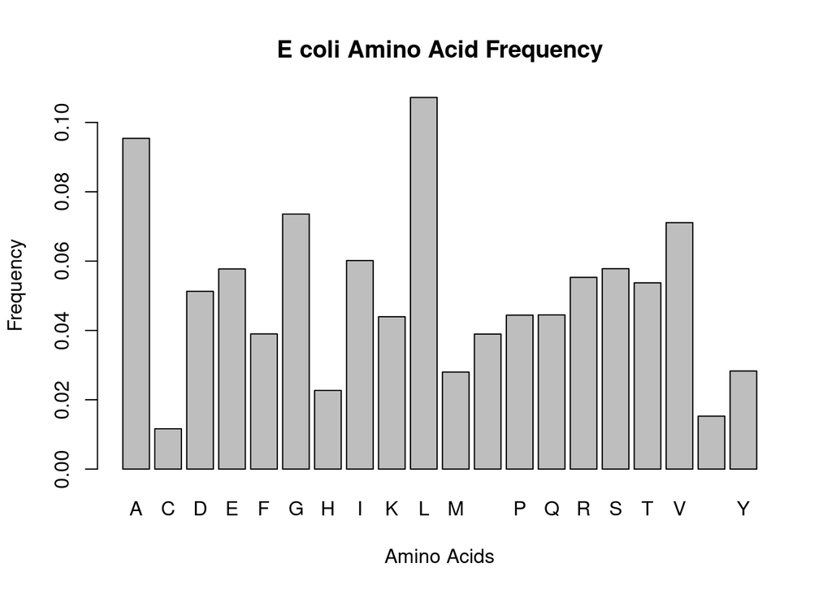

```r
barplot(e_coli_aa_prop,xlab="Amino Acids",ylab="Frequency", main="E coli Amino Acid Frequency")
```

The frequency of each amino acid is displayed as a barplot with the barplot() command. The plot heading is determined with “main”, the x and y axis labels are determined using “xlab” and “ylab” respectively.

### Bar plot for *Salmonella* amino acid frequency

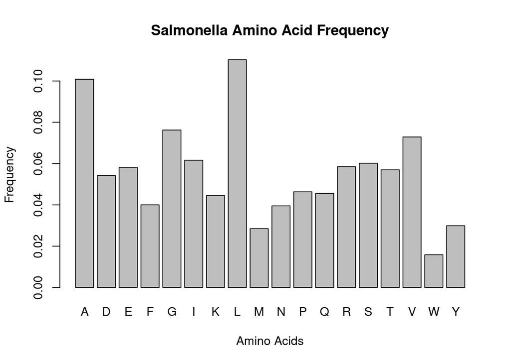

```r
barplot(salmonella_aa_prop,xlab="Amino Acids",ylab="Frequency", main="Salmonella Amino Acid Frequency")
```

The frequency of each amino acid is displayed as a barplot with the barplot() command. The plot heading is determined with “main”, the x and y axis labels are determined using “xlab” and “ylab” respectively.

Nucleotide frequency and their distributions, as shown in the barplots, are quite similar between the 2 organisms indicating functional similarities. As the amino acid barplots indicate, most amino acid frequencies across the two organisms are similar, however, *E.coli* has data for both C and H where *Salmonella* does not.

## **Q5**

### Codon usage table for Salmonella

```r
codon_salmonella <- readSet(file="https://ftp.ensemblgenomes.ebi.ac.uk/pub/bacteria/release-59/fasta/bacteria_50_collection/salmonella_enterica_subsp_enterica_serovar_weltevreden_gca_005518735/cds/Salmonella_enterica_subsp_enterica_serovar_weltevreden_gca_005518735.ASM551873v1.cds.all.fa.gz")
codon_tab_salmonella <- codonTable(codon_salmonella)
head(codon_tab_salmonella)
```

```
## codonTable instance with codon counts from 6 sequences.
##                                                                                                                                                                                                                                                       ID
## 1 ENSB:rzMRPrOXj2f6n3A cds primary_assembly:ASM551873v1:contig00038:4502:4918:-1 gene:ENSB:rzMRPrOXj2f6n3A gene_biotype:protein_coding transcript_biotype:protein_coding gene_symbol:csgF description:Curli production assembly/transport component CsgF
## 2                        ENSB:x3MzlaR1iM6Op6v cds primary_assembly:ASM551873v1:contig00003:321788:322189:1 gene:ENSB:x3MzlaR1iM6Op6v gene_biotype:protein_coding transcript_biotype:protein_coding gene_symbol:stpA description:DNA-binding protein StpA
## 3                 ENSB:btfdQZt4_vWjqOV cds primary_assembly:ASM551873v1:contig00009:90040:92652:1 gene:ENSB:btfdQZt4_vWjqOV gene_biotype:protein_coding transcript_biotype:protein_coding gene_symbol:sfmD description:Outer membrane usher protein SfmD
## 4   ENSB:IZ64ldiL3-oOAYf cds primary_assembly:ASM551873v1:contig00025:33632:34945:1 gene:ENSB:IZ64ldiL3-oOAYf gene_biotype:protein_coding transcript_biotype:protein_coding gene_symbol:gatC_2 description:PTS system galactitol-specific EIIC component
## 5                                                                                ENSB:9CMZHlFso1POuRQ cds primary_assembly:ASM551873v1:contig00002:37459:37623:1 gene:ENSB:9CMZHlFso1POuRQ gene_biotype:protein_coding transcript_biotype:protein_coding
## 6       ENSB:WDGo7WHsQXy-ZVK cds primary_assembly:ASM551873v1:contig00004:270379:271296:1 gene:ENSB:WDGo7WHsQXy-ZVK gene_biotype:protein_coding transcript_biotype:protein_coding gene_symbol:rhaS_3 description:HTH-type transcriptional activator RhaS
##   length AAA AAC AAG AAT ACA ACC ACG ACT AGA AGC AGG AGT ATA ATC ATG ATT CAA
## 1    139   4   7   0   8   0   8   4   1   2   1   0   0   0   4   4   4   4
## 2    134   9   2   2   5   0   2   2   2   1   0   1   0   0   2   7   4   2
## 3    871  17  22   5  25   6  24  23   3   1  37   3  11   6  11  10  20  17
## 4    438  14   5   1   3   0  14   7   2   0   4   0   4   5  22  23  29   3
## 5     55   3   0   0   0   1   0   2   0   0   0   0   0   2   0   4   1   0
## 6    306  12   4   4   7   1   5   5   0   2   9   0   3   2   4  16  15   5
```

[output cut: 21 more lines]

The *Salmonella* Fasta file was read by the command readSet () to create a codon table, which the first six values of each codon can be seen above.

### Codon usage table for E-coli

```r
codon_e_coli <- readSet(file="http://ftp.ensemblgenomes.org/pub/bacteria/release-53/fasta/bacteria_0_collection/escherichia_coli_str_k_12_substr_mg1655_gca_000005845/cds/Escherichia_coli_str_k_12_substr_mg1655_gca_000005845.ASM584v2.cds.all.fa.gz")
codon_tab_e_coli <- codonTable(codon_e_coli)
head(codon_tab_e_coli)
```

```
## codonTable instance with codon counts from 6 sequences.
##                                                                                                                                                                                                               ID
## 1                          AAC73112 cds chromosome:ASM584v2:Chromosome:190:255:1 gene:b0001 gene_biotype:protein_coding transcript_biotype:protein_coding gene_symbol:thrL description:thr operon leader peptide
## 2 AAC73113 cds chromosome:ASM584v2:Chromosome:337:2799:1 gene:b0002 gene_biotype:protein_coding transcript_biotype:protein_coding gene_symbol:thrA description:fused aspartate kinase/homoserine dehydrogenase 1
## 3                                AAC73114 cds chromosome:ASM584v2:Chromosome:2801:3733:1 gene:b0003 gene_biotype:protein_coding transcript_biotype:protein_coding gene_symbol:thrB description:homoserine kinase
## 4                               AAC73115 cds chromosome:ASM584v2:Chromosome:3734:5020:1 gene:b0004 gene_biotype:protein_coding transcript_biotype:protein_coding gene_symbol:thrC description:threonine synthase
## 5           AAC73116 cds chromosome:ASM584v2:Chromosome:5234:5530:1 gene:b0005 gene_biotype:protein_coding transcript_biotype:protein_coding gene_symbol:yaaX description:DUF2502 domain-containing protein YaaX
## 6         AAC73117 cds chromosome:ASM584v2:Chromosome:5683:6459:-1 gene:b0006 gene_biotype:protein_coding transcript_biotype:protein_coding gene_symbol:yaaA description:peroxide stress resistance protein YaaA
##   length AAA AAC AAG AAT ACA ACC ACG ACT AGA AGC AGG AGT ATA ATC ATG ATT CAA
## 1     22   1   1   0   0   1   7   0   0   0   1   0   0   0   1   1   3   0
## 2    821  22  16  12  22   2  19   8   5   0  12   2   3   1  15  23  30  11
## 3    311   3   6   7   6   2   3   3   1   0   4   1   3   0   9  10   7   3
## 4    429  17  11   5   8   2  11   6   4   0   6   0   3   0   9   8   8   5
## 5     99   5   0   2   2   0   0   1   0   0   0   0   0   1   1   2   1   2
## 6    259  11   4   7   9   0   6   6   1   0   7   0   1   0   9   6   8   5
```

[output cut: 21 more lines]

The *E.coli* Fasta file was read by the command readSet () to create a codon table, which the first six values of each codon can be seen above.

### Codon bias for salmonella

```r
salmonella_milc <- MILC(codon_tab_salmonella)
head(salmonella_milc)
```

```
##           self
## [1,] 0.7199963
## [2,] 0.5252359
## [3,] 0.5502128
## [4,] 0.5231461
## [5,] 0.7078510
## [6,] 0.5652358
```

The codon bias of *Salmonella’s* first 6 genes is shown above, to find this the MILC() command was used, with the head() command.

### Codon bias for E-coli

```r
e_coli_milc <- MILC(codon_tab_e_coli)
head(e_coli_milc)
```

```
##           self
## [1,] 0.4690096
## [2,] 0.5160116
## [3,] 0.5034795
## [4,] 0.5419666
## [5,] 0.4711169
## [6,] 0.5398071
```

The codon bias of *E.coli’s* first 6 genes is shown above, to find this the MILC() command was used, with the head() command.

### Histogram of Codon bias in *Salmonella*

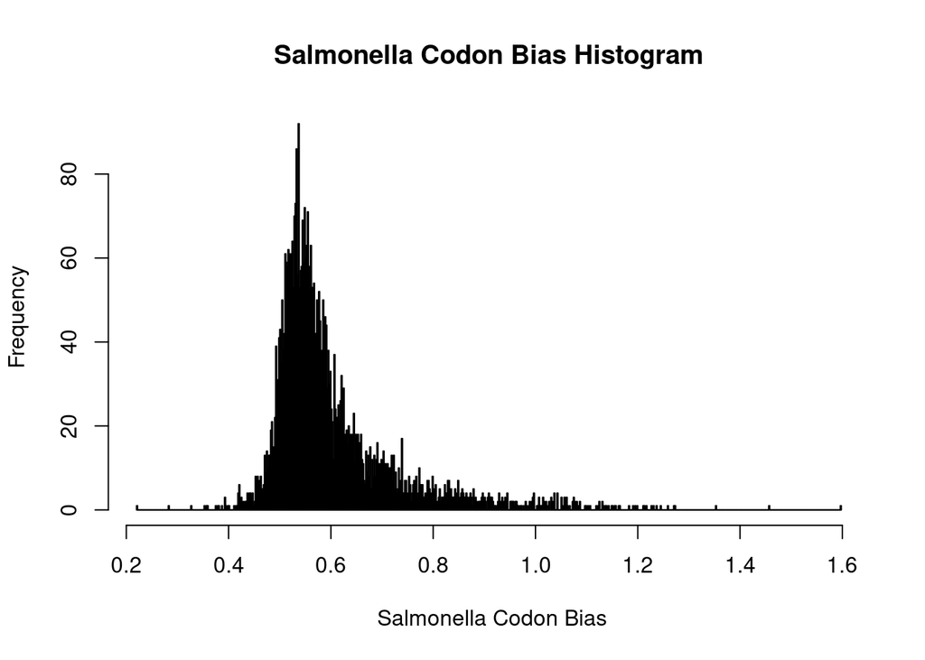

```r
hist(salmonella_milc,
     main = "Salmonella Codon Bias Histogram",
     xlab = " Salmonella Codon Bias", ylab = "Frequency",breaks=500)
```

Shown above is a histogram displaying the *Salmonella* Codon Bias, this was visualised with the hist() command.

### Histogram of Codon bias in *E.coli*

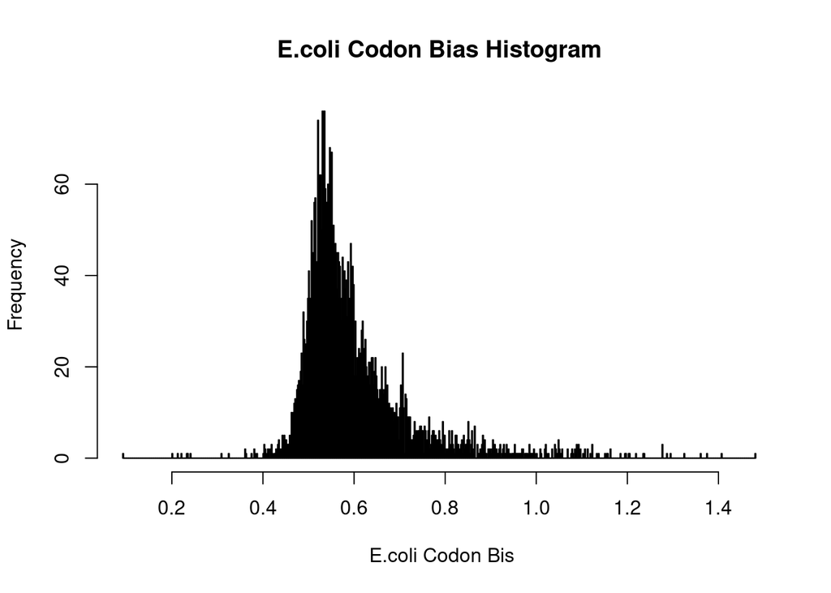

```r
hist(e_coli_milc,
     main = "E.coli Codon Bias Histogram",
     xlab = " E.coli Codon Bis", ylab = "Frequency",breaks=500)
```

Shown above is a histogram displaying the *E.coli* Codon Bias, this was visualised with the hist() command.

The *Salmonella* histogram shows a higher frequency of codon bias around 0.5 to 0.6,with the spread of bias from approximately 0.2 to 1.6. The histogram of *E.coli* shows a higher frequency of codon bias around 0.5 to 0.6, with the spread of bias being from approximately 0.2 to 1.4. The Codon bias for both *Salmonella* and *E.coli* show a similar histogram shape, indicating a similar codon bias between both organisms.

## **Q6**

### Creating amino acid alphabet and unlisting *Salmonella* proteins

```r
salmonella_prot <- lapply(salmonella, translate)
salmonella_prots <- unlist(salmonella_prot)

head(salmonella_prots)
```

```
## ENSB:rzMRPrOXj2f6n3A1 ENSB:rzMRPrOXj2f6n3A2 ENSB:rzMRPrOXj2f6n3A3
##                   "M"                   "R"                   "V"
## ENSB:rzMRPrOXj2f6n3A4 ENSB:rzMRPrOXj2f6n3A5 ENSB:rzMRPrOXj2f6n3A6
##                   "K"                   "H"                   "A"
```

```r
aa <- unique(salmonella_prot[[2]])
aa <- aa[aa != "*"]
```

### Creating data frame of 3 length K-mers in Salmonella

```r
salmonella_counts_3 <- count(salmonella_prots,wordsize=3,alphabet=aa)
head(salmonella_counts_3)
```

```
##
##  AAA  AAD  AAE  AAF  AAG  AAI
## 1575  630  782  534 1185  893
```

```r
df_salmonella_counts_3 <- as.data.frame(salmonella_counts_3)
head(df_salmonella_counts_3)
```

```
##   Var1 Freq
## 1  AAA 1575
## 2  AAD  630
## 3  AAE  782
## 4  AAF  534
## 5  AAG 1185
## 6  AAI  893
```

A data frame of 3 length K-mers was created for *Salmonella* to be able to be able to sort over represented and underrepresented 3 length k-mers.The data frame was created with the as.data.frame() command.

### Creating data frame of 3 length K-mers in E.coli

```r
e_coli_prot <- lapply(e_coli, translate)
e_coli_prots <- unlist(e_coli_prot)

head(e_coli_prots)
```

```
## AAC731121 AAC731122 AAC731123 AAC731124 AAC731125 AAC731126
##       "M"       "K"       "R"       "I"       "S"       "T"
```

```r
e_coli_counts_3 <- count(e_coli_prots,wordsize=3,alphabet=aa)
head(e_coli_counts_3)
```

```
##
##  AAA  AAD  AAE  AAF  AAG  AAI
## 1338  568  749  481 1075  863
```

```r
df_e_coli_counts_3 <- as.data.frame(e_coli_counts_3)
head(df_e_coli_counts_3)
```

```
##   Var1 Freq
## 1  AAA 1338
## 2  AAD  568
## 3  AAE  749
## 4  AAF  481
## 5  AAG 1075
## 6  AAI  863
```

A data frame of 3 length K-mers was created for *E.coli* to be able to be able to sort over represented and underrepresented 3 length k-mers.The data frame was created with the as.data.frame() command.

### Top 10 most overrepressented 3 length K-mers in Salmonella

```r
over_salmonella_counts_3 <-arrange(df_salmonella_counts_3,-Freq)
head(over_salmonella_counts_3,10)
```

```
##    Var1 Freq
## 1   LLA 1973
## 2   ALL 1950
## 3   ALA 1949
## 4   LAA 1752
## 5   AAL 1749
## 6   LLL 1723
## 7   LAL 1700
## 8   AAA 1575
## 9   LAG 1273
## 10  TLL 1205
```

### Top 10 most overrepressented 3 length K-mers in E.coli

```r
over_e_coli_counts_3 <-arrange(df_e_coli_counts_3,-Freq)
head(over_e_coli_counts_3,10)
```

```
##    Var1 Freq
## 1   LLA 1817
## 2   ALL 1744
## 3   ALA 1740
## 4   LAA 1601
## 5   AAL 1594
## 6   LLL 1594
## 7   LAL 1536
## 8   AAA 1338
## 9   LAG 1178
## 10  TLL 1102
```

The 3 length K-mers overrepresented in *Salmonella* and *E.coli*, are all the same, and in the same order of overrepresentation, however they do vary on the amount of representation In the gene. The identification of the overrepresented 3 length K-mers were found by using the arrange() command, with a - negative frequency, to order the data frame in decreasing order.

### Top 10 most underrepressented 3 length K-mers in Salmonella

```r
under_salmonella_counts_3 <-arrange(df_salmonella_counts_3,Freq)
head(under_salmonella_counts_3,10)
```

```
##    Var1 Freq
## 1   WWW    5
## 2   WMW    6
## 3   YMW    6
## 4   NWW    7
## 5   MWP    8
## 6   WWT    8
## 7   MWN    9
## 8   MWW    9
## 9   WYW    9
## 10  KWW   10
```

### Top 10 most underrepressented 3 length K-mers in E.coli

```r
under_e_coli_counts_3 <-arrange(df_e_coli_counts_3,Freq)
head(under_e_coli_counts_3,10)
```

```
##    Var1 Freq
## 1   WMW    5
## 2   WWW    6
## 3   YMW    6
## 4   MWW    7
## 5   NWW    7
## 6   WWT    7
## 7   FKW    9
## 8   WWM    9
## 9   WYW    9
## 10  KWW   10
```

### Creating data frame of 4 length K-mers in Salmonella

```r
salmonella_counts_4 <- count(salmonella_prots,wordsize=4,alphabet=aa)
head(salmonella_counts_4)
```

```
##
## AAAA AAAD AAAE AAAF AAAG AAAI
##  196   58   81   58  141  104
```

```r
df_salmonella_counts_4 <- as.data.frame(salmonella_counts_4)
head(df_salmonella_counts_4)
```

```
##   Var1 Freq
## 1 AAAA  196
## 2 AAAD   58
## 3 AAAE   81
## 4 AAAF   58
## 5 AAAG  141
## 6 AAAI  104
```

A data frame of 4 length K-mers was created for *Salmonella* to be able to be able to sort over represented and underrepresented 4 length k-mers.The data frame was created with the as.data.frame() command.

### Creating data frame of 4 length K-mers in E.coli

```r
e_coli_counts_4 <- count(e_coli_prots,wordsize=4,alphabet=aa)
head(e_coli_counts_4)
```

```
##
## AAAA AAAD AAAE AAAF AAAG AAAI
##  148   56   76   38  100   88
```

```r
df_e_coli_counts_4 <- as.data.frame(e_coli_counts_4)
head(df_e_coli_counts_4)
```

```
##   Var1 Freq
## 1 AAAA  148
## 2 AAAD   56
## 3 AAAE   76
## 4 AAAF   38
## 5 AAAG  100
## 6 AAAI   88
```

A data frame of 4 length K-mers was created for *E.coli* to be able to be able to sort over represented and underrepresented 4 length k-mers.The data frame was created with the as.data.frame() command.

### Top 10 most overrepressented 4 length K-mers in Salmonella

```r
over_salmonella_counts_4 <-arrange(df_salmonella_counts_4,-Freq)
head(over_salmonella_counts_4,10)
```

```
##    Var1 Freq
## 1  ALAA  255
## 2  ALLA  252
## 3  LLAL  239
## 4  AALA  238
## 5  LAAL  233
## 6  LLLL  224
## 7  LLAA  218
## 8  LALA  214
## 9  ALAL  213
## 10 LALL  212
```

### Top 10 most overrepressented 4 length K-mers in E.coli

```r
over_e_coli_counts_4 <-arrange(df_e_coli_counts_4,-Freq)
head(over_e_coli_counts_4,10)
```

```
##    Var1 Freq
## 1  LAAL  234
## 2  ALAA  233
## 3  LLAL  215
## 4  LLLL  209
## 5  AALA  207
## 6  LLAA  206
## 7  LLLA  197
## 8  LALA  196
## 9  LALL  195
## 10 ALLA  193
```

The 4 length K-mers overrepresented in *Salmonella* and *E.coli*, share similar K-mers, with majority of the K-mers shown being in both organisms, with a few exceptions of ‘ALAL’ in *Salmonella* and ‘LLLA’ in *E.coli*, the shared K-mers do vary on the amount of representation In the gene.The identification of the over represented 4 length K-mers were found by using the arrange() command, with a - negative frequency, to order the data frame in decreasing order.

### Top 10 most underrepressented 4 length K-mers in Salmonella

```r
under_salmonella_counts_4 <-arrange(df_salmonella_counts_4,Freq)
head(under_salmonella_counts_4,10)
```

```
##    Var1 Freq
## 1  ADPW    0
## 2  AFKM    0
## 3  AFMW    0
## 4  AGWW    0
## 5  AKQW    0
## 6  AKWN    0
## 7  AKWP    0
## 8  AKWW    0
## 9  AMMF    0
## 10 AMNW    0
```

### Top 10 most underrepressented 4 length K-mers in E.coli

```r
under_e_coli_counts_4 <-arrange(df_e_coli_counts_4,Freq)
head(under_e_coli_counts_4,10)
```

```
##    Var1 Freq
## 1  AEMW    0
## 2  AEWW    0
## 3  AEWY    0
## 4  AFMK    0
## 5  AFWI    0
## 6  AKWF    0
## 7  AKWT    0
## 8  AMMW    0
## 9  AMNW    0
## 10 AMWE    0
```

The 4 length K-mers underrepresented in *Salmonella* and *E.coli*, all show 0 representation, as there is just 10 K-mers shown, there are other K-mers also at 0 representation, so while there are limited shared K-mers between both organisms shown in the results, more shared K-mers of underrepresentation cannot be ruled out.The identification of the underrepresented 4 length K-mers were found by using the arrange() command, with a + positive frequency, to order the data frame in increasing order.

### Creating data frame of 5 length K-mers in Salmonella

```r
salmonella_counts_5 <- count(salmonella_prots,wordsize=5,alphabet=aa)
head(salmonella_counts_5)
```

```
##
## AAAAA AAAAD AAAAE AAAAF AAAAG AAAAI
##    45    13     9     4    17     8
```

```r
df_salmonella_counts_5 <- as.data.frame(salmonella_counts_5)
head(df_salmonella_counts_5)
```

```
##    Var1 Freq
## 1 AAAAA   45
## 2 AAAAD   13
## 3 AAAAE    9
## 4 AAAAF    4
## 5 AAAAG   17
## 6 AAAAI    8
```

A data frame of 5 length K-mers was created for *Salmonella* to be able to be able to sort over represented and underrepresented 5 length k-mers.The data frame was created with the as.data.frame() command.

### Creating data frame of 5 length K-mers in E.coli

```r
e_coli_counts_5 <- count(e_coli_prots,wordsize=5,alphabet=aa)
head(e_coli_counts_5)
```

```
##
## AAAAA AAAAD AAAAE AAAAF AAAAG AAAAI
##    27     5    10     4    13    10
```

```r
df_e_coli_counts_5 <- as.data.frame(e_coli_counts_5)
head(df_e_coli_counts_5)
```

```
##    Var1 Freq
## 1 AAAAA   27
## 2 AAAAD    5
## 3 AAAAE   10
## 4 AAAAF    4
## 5 AAAAG   13
## 6 AAAAI   10
```

A data frame of 5 length K-mers was created for *E.coli* to be able to be able to sort over represented and underrepresented 5 length k-mers.The data frame was created with the as.data.frame() command.

### Top 10 most overrepressented 5 length K-mers in Salmonella

```r
over_salmonella_counts_5 <-arrange(df_salmonella_counts_5,-Freq)
head(over_salmonella_counts_5,10)
```

```
##     Var1 Freq
## 1  GKSTL   55
## 2  AAAAA   45
## 3  LLLAL   43
## 4  AALAA   42
## 5  GSGKS   40
## 6  AALLA   39
## 7  ALAAL   37
## 8  LAAAL   36
## 9  ALALA   33
## 10 LLALA   33
```

### Top 10 most overrepressented 5 length K-mers in E.coli

```r
over_e_coli_counts_5 <-arrange(df_e_coli_counts_5,-Freq)
head(over_e_coli_counts_5,10)
```

```
##     Var1 Freq
## 1  GKSTL   58
## 2  GSGKS   42
## 3  AALAA   37
## 4  LLAAL   37
## 5  SGSGK   37
## 6  LLLDE   35
## 7  LAAAL   34
## 8  LLLAL   34
## 9  LLLLL   34
## 10 LDEPT   33
```

### Top 10 most underrepressented 5 length K-mers in Salmonella

```r
under_salmonella_counts_5 <-arrange(df_salmonella_counts_5,Freq)
head(under_salmonella_counts_5,10)
```

```
##     Var1 Freq
## 1  AAAAW    0
## 2  AAADP    0
## 3  AAADQ    0
## 4  AAADS    0
## 5  AAAEW    0
## 6  AAAEY    0
## 7  AAAFK    0
## 8  AAAFM    0
## 9  AAAIF    0
## 10 AAAIW    0
```

### Top 10 most underrepressented 5 length K-mers in E.coli

```r
under_e_coli_counts_5 <-arrange(df_e_coli_counts_5,Freq)
head(under_e_coli_counts_5,10)
```

```
##     Var1 Freq
## 1  AAAAW    0
## 2  AAADF    0
## 3  AAADM    0
## 4  AAADN    0
## 5  AAADS    0
## 6  AAADW    0
## 7  AAAEE    0
## 8  AAAEW    0
## 9  AAAFD    0
## 10 AAAFK    0
```

The 5 length K-mers underrepresented in *Salmonella* and *E.coli*, all show 0 representation, as there is just 10 K-mers shown, there are other K-mers also at 0 representation, so while there are limited shared K-mers between both organisms shown in the results, more shared K-mers of underrepresentation cannot be ruled out.The identification of the underrepresented 5 length K-mers were found by using the arrange() command, with a + positive frequency, to order the data frame in increasing order.

### Plot of K-mers of 3 amino acids overrepresented of *Salmonella* compared to *E.coli*

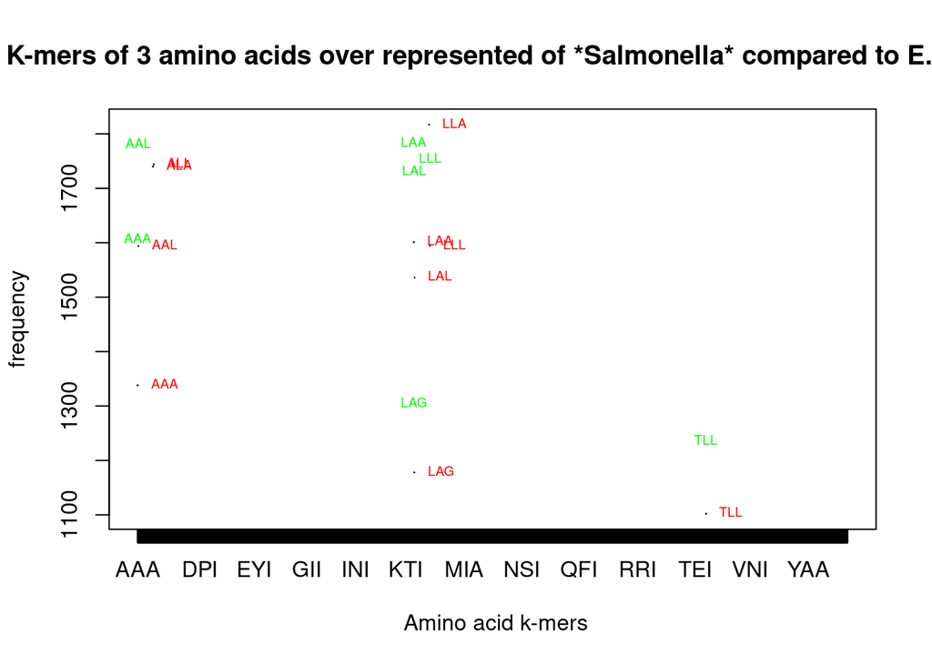

```r
ecoli_3_over <- data.frame(over_e_coli_counts_3[,-1], row.names=over_e_coli_counts_3[,1])
salmonella_3_over <- data.frame(over_salmonella_counts_3[,-1], row.names=over_salmonella_counts_3[,1])

plot(head(over_e_coli_counts_3,10),head(over_salmonella_counts_3,10),
     main = "K-mers of 3 amino acids over represented of *Salmonella* compared to E.coli",
     xlab = " Amino acid k-mers", ylab = "frequency")

text(head(over_e_coli_counts_3,10),
     labels = row.names(head(ecoli_3_over,10)),
     cex = 0.6, pos = 4, col = "red")
text(head(over_salmonella_counts_3,10),
     labels = row.names(head(salmonella_3_over,10)),
     cex = 0.6, pos = 3, col = "green")
```

The plot above shows the overrepresented 3 Amino acid length K-mers in both *Salmonella* (Green) and *E.coli* (red). The plot shows the labelled K-mers and their corresponding frequency, and the closeness in shared K-mers between both organisms, but also shows the variation in frequency between the K-mers when expressed in *Salmonella* compared to *E.coli*.

### Plot of K-mers of 3 amino acids underrepresented in *Salmonella* compared to *E.coli*

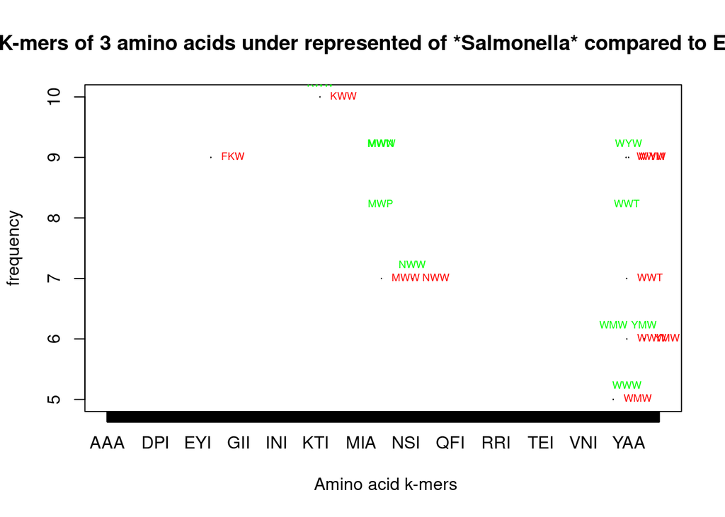

```r
ecoli_3_under <- data.frame(under_e_coli_counts_3[,-1], row.names=under_e_coli_counts_3[,1])
salmonella_3_under <- data.frame(under_salmonella_counts_3[,-1], row.names=under_salmonella_counts_3[,1])

plot(head(under_e_coli_counts_3,10),head(under_salmonella_counts_3,10),
     main = "K-mers of 3 amino acids under represented of *Salmonella* compared to E.coli",
     xlab = " Amino acid k-mers", ylab = "frequency")

text(head(under_e_coli_counts_3,10),
     labels = row.names(head(ecoli_3_under,10)),
     cex = 0.6, pos = 4, col = "red")
text(head(under_salmonella_counts_3,10),
     labels = row.names(head(salmonella_3_under,10)),
     cex = 0.6, pos = 3, col = "green")
```

The plot above shows the underrepresented 3 Amino acid length K-mers in both *Salmonella* (green) and *E.coli* (red). The plot shows the labelled K-mers and their corresponding frequency, and the closeness in shared K-mers between both organisms, but also shows the variation in frequency between the K-mers when expressed in *Salmonella* compared to *E.coli*.

The variation in K-mer expression in *Salmonella* and *E.coli* is due to the differences in nucleotide sequences which create the proteins, which then create the 3,4,5 length K-mers.